# team.Rmd

chrlwhtng

4/8/2020

```r
library(tidyverse)
```

```r
library(ggplot2)


acc <- read.csv("https://raw.githubusercontent.com/xdaiISU/ds202materials/master/hwlabs/fars2017/accident.csv", stringsAsFactors = FALSE)

per <- read.csv("https://raw.githubusercontent.com/xdaiISU/ds202materials/master/hwlabs/fars2017/person.csv", stringsAsFactors = FALSE)
```

1. Are there some days of the week where more accidents happen than on others (use variable DAY_WEEK)?

```r
acc[1, ]
```

```
##   STATE ST_CASE VE_TOTAL VE_FORMS PVH_INVL PEDS PERNOTMVIT PERMVIT PERSONS
## 1     1   10001        1        1        0    0          0       1       1
##   COUNTY CITY DAY MONTH YEAR DAY_WEEK HOUR MINUTE NHS RUR_URB FUNC_SYS RD_OWNER
## 1     73  330  19     2 2017        1   23     35   1       2        1        1
##   ROUTE TWAY_ID TWAY_ID2 MILEPT LATITUDE  LONGITUD SP_JUR HARM_EV MAN_COLL
## 1     1   I-459              10 33.33566 -87.00709      0      38        0
##   RELJCT1 RELJCT2 TYP_INT WRK_ZONE REL_ROAD LGT_COND WEATHER1 WEATHER2 WEATHER
## 1       0       1       1        0        3        2        1        0       1
##   SCH_BUS    RAIL NOT_HOUR NOT_MIN ARR_HOUR ARR_MIN HOSP_HR HOSP_MN CF1 CF2 CF3
## 1       0 725409J       99      99       99      99      88      88   0   0   0
##   FATALS DRUNK_DR
## 1      1        0
```

```r
#Record one is on Feb 19, 2017, a Sunday. DAY_WEEK is 1, meaning 7 is Saturday, etc.

table(acc$DAY_WEEK)
```

```
##
##    1    2    3    4    5    6    7
## 5360 4374 4347 4314 4621 5358 5873
```

This table shows that most accidents took place on weekends. There were roughly equal number of crashes between Monday (2) and Thursday (4). The day with the most crashes was Saturday.

2. What time of the day do accidents happen (use variable HOUR)?

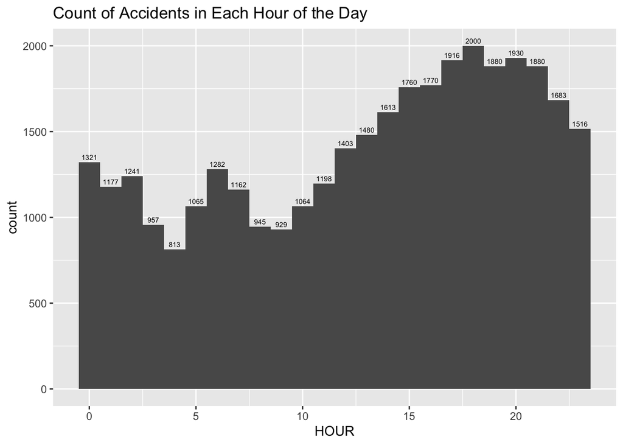

```r
#For whatever reason, HOUR includes 99as an hour, and I'm not sure how to include that.
acc %>% filter(HOUR != 99) %>% ggplot(aes(x=HOUR)) + geom_histogram(binwidth=1) +
  geom_text(stat='count', aes(label=stat(count), vjust=-.5), size=2) +
  ggtitle("Count of Accidents in Each Hour of the Day")
```

Based on this histogram, it appears that hour 18 (6 PM) is the most common time for accidents to occur. In fact, it appears that it is most likely to get in an accident in the afternoon and night hours than in the moring half of the day.

3. What is the number of accidents with at least one drunk driver (use variable DRUNK_DR)?

```r
acc %>% filter(DRUNK_DR >= 1) %>% count()
```

```
## # A tibble: 1 x 1
##       n
##   <int>
## 1  8769
```

There are 8,769 accidents with at least 1 drunk driver in this data set.

4. In the person table, identify drivers (PER_TYP == 1, see FARS manual) and subset on them.

```r
per <- per %>% filter(PER_TYP == 1)
```

5. Join accident and person table (work out which variable(s) to use)

```r
dat <- acc %>% full_join(per, by=c('ST_CASE', 'COUNTY', 'DAY', 'MONTH', 'HOUR', 'MINUTE'))
```

6. Tally the number of accidents by day of the week (DAY_WEEK), hour of the day (HOUR) and gender (SEX). Visualize the results.

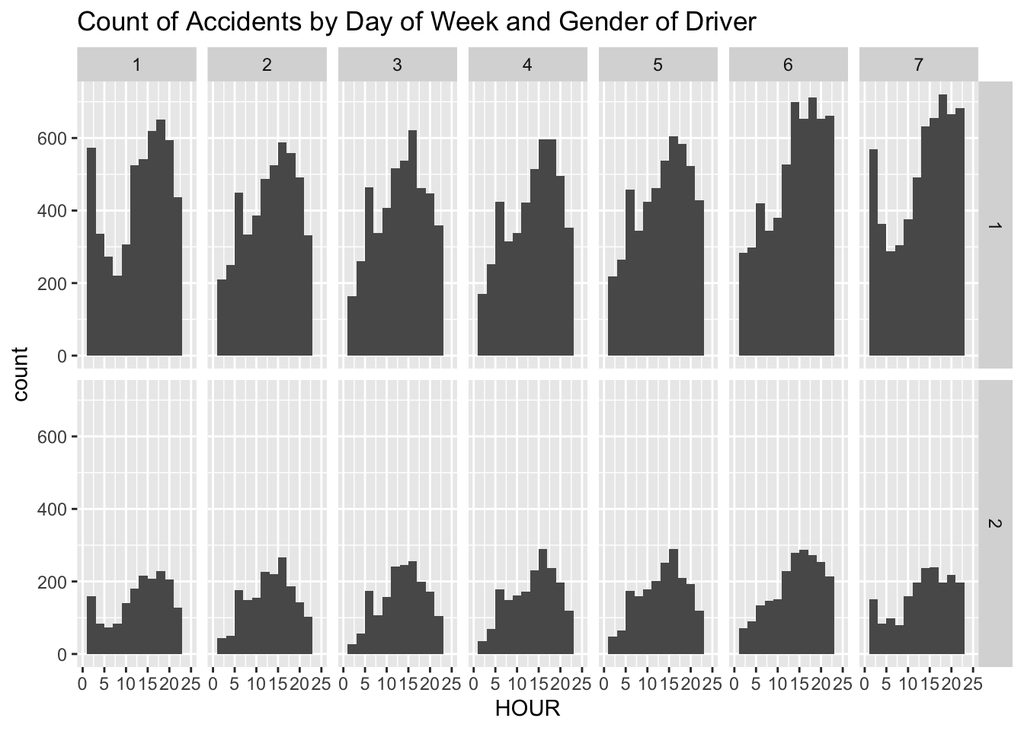

```r
dat %>% filter(SEX == 1 | SEX == 2) %>% ggplot(aes(x=HOUR)) +
  geom_histogram(binwidth=2) + facet_grid(SEX~DAY_WEEK) +
  xlim(c(0, 25)) +
  ggtitle("Count of Accidents by Day of Week and Gender of Driver")
```

7. Now plot a choropleth map of accidents on a county level

```r
GLC <-readxl::read_xlsx("FRPP.xlsx")
GLC$`State Code` <- as.numeric(GLC$`State Code`)
GLC$`City Code` <- as.numeric(GLC$`City Code`)
GLC$`County Code` <- as.numeric(GLC$`County Code`)
dat <- dat %>% rename(`State Code`  = STATE.x ,`County Code`=COUNTY)
dat <- left_join(dat, GLC) %>% select(-`Old City Name`, -`Date Record Added`,-`City Name`, -`City Code`)
```

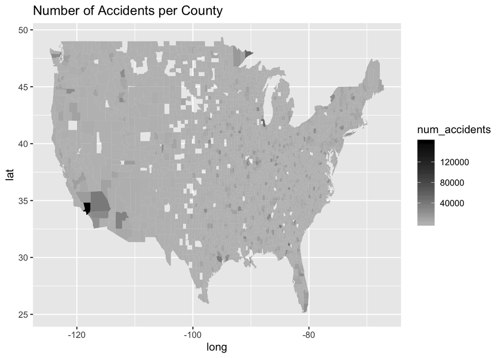

```r
dat1 <- dat %>% group_by(`County Name`) %>% summarize(num_accidents= n()) %>% rename(subregion = `County Name`) %>% mutate(subregion = tolower(`subregion`))
county <- map_data("county")
dat1 <- left_join(dat1, county)
dat1 %>% ggplot(aes(x= long, y = lat, fill = num_accidents)) + geom_polygon(aes(group = group))+ scale_fill_gradient(low ="grey", high = "black") + ggtitle("Number of Accidents per County")
```

Read the description for the STATE and COUNTY columns in the FARS manual. The state & county codes are Geographic Locator Codes (GLCs) from the General Services Administration’s (GSA) publication Use readxl::read_xlsx to read in the GLCs

8. Visualize the number of accidents in each county using a choropleth map. To do this, you need to join the accident data, GLCs, and appropriate map data.

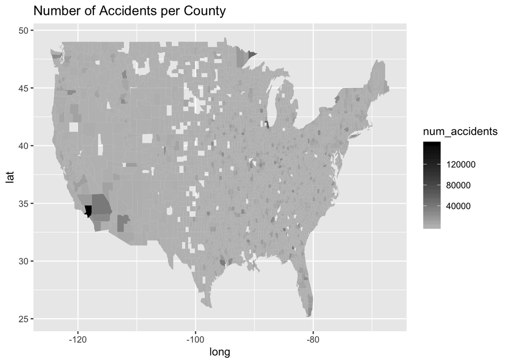

```r
dat1 %>% ggplot(aes(x= long, y = lat, fill = num_accidents)) + geom_polygon(aes(group = group))+ scale_fill_gradient(low ="grey", high = "black") + ggtitle("Number of Accidents per County")
```

9. Can you find seasonal trends in accident occurrences in different states? Is summer or winter more dangerous? Why?

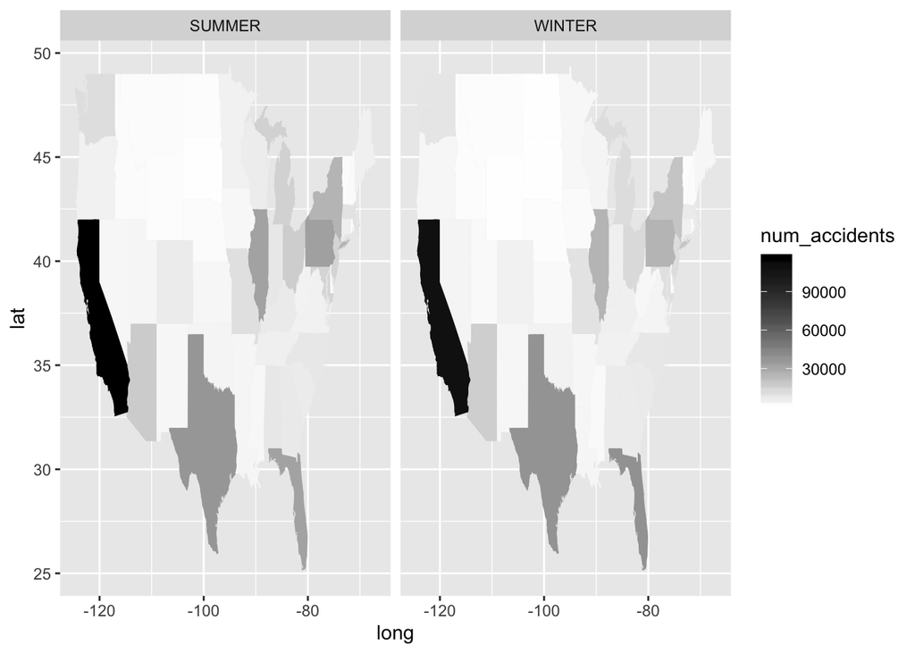

```r
#Taking out rows that are not summer or winter "so months that are not 11, 12, 1, 2, 6, 7, 8, 9
seasons <- dat %>% filter(MONTH %in% c(11,12,1,2,6,7,8,9)) %>% mutate(Season = if_else(MONTH %in% c(11,12,1,2), "WINTER","SUMMER"))
seasons <- seasons %>% group_by(Season, `State Name`) %>% summarize(num_accidents = n()) %>% rename(region = `State Name`) %>% mutate(region = tolower(region))
states <- map_data("state")
seasons <- left_join(seasons, states)
seasons %>% ggplot(aes(x = long, y = lat, fill = num_accidents)) + geom_polygon(aes(group = group)) + facet_wrap(~Season) + scale_fill_gradient(low = "white", high = "black")
```

The trend seems to be that summer is a little more dangerous than winter as more accidents occur during the summer months rather than winter months. This could be for a multitude of reasons one being more drivers on the roads and people not paying as much attention. The numbers of accidents between summer and winter did not vary that much as both values were about the same for each state.